# STAT 486/586

Jarad Niemi

2023-02-28

R code

```r
library("tidyverse"); theme_set(theme_bw())
library("scales") # for breaks_pretty()
```

# Mean

## Central Limit Theorem

If we have $X_i$ for $i=1,\ldots,n$ that are independent and identically distributed with $E[X_i] = \mu$ and $Var[X_i] = \sigma^2 < \infty$, then
$$\frac{\overline{X}-\mu}{s/\sqrt{n}} \stackrel{d}{\to} N(0,1) \quad
\mbox{as } n\to \infty.$$
Thus, for large enough n,
$$\overline{X} \stackrel{\cdot}{\sim} N(\mu, s^2/n)$$
where $\stackrel{\cdot}{\sim}$ means “approximately distributed.”

This result is the basis of a common asymptotic confidence interval formula for $\mu$:
$$\overline{x} \pm z s/\sqrt{n}$$
where $z$ is a critical value that depends on the confidence level of the confidence interval.

## Examples

Let’s first make a function to construct the data.frame we’ll need to plot to visualize

```r
create_mean_dataframe <- function(x) {
  data.frame(n = 1:length(x)) %>%
    mutate(
      xbar = cumsum(x)/n,
      s    = cumsum((x-xbar)^2)/(n-1),
      lcl  = xbar - qnorm(.975)*s/sqrt(n),
      ucl  = xbar + qnorm(.975)*s/sqrt(n)
    )
}
```

As long as we’re at it, let’s make a function to create the plot

```r
plot_mean <- function(d, truth = NULL) {
  g <- ggplot(d, aes(x = n, y = xbar, ymin = lcl, ymax = ucl)) +
    geom_ribbon(fill = "blue", alpha = 0.3) +
    geom_line(color = "blue")

  if (!is.null(truth))
    g <- g + geom_hline(yintercept = truth, color = "red", linetype = 2)

  return(g)
}
```

### Normal mean

Let $X_i \stackrel{ind}{\sim} N(\mu, \sigma^2)$. If we sample enough $X_i$, then we can learn about $\mu$.

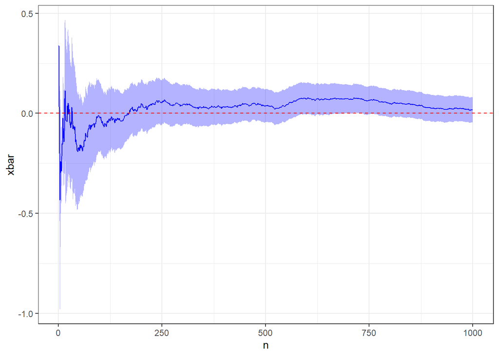

```r
m <- 0
s <- 1

x <- rnorm(1e3, mean = m, sd = 1)

d <- create_mean_dataframe(x)

plot_mean(d, truth = m)
```

### Truncated normal mean

Suppose our random variables have a normal distribution but are truncated between two values $a$ and $b$. We might write this as $N(\mu,\sigma^2)[a,b]$.

Let’s first construct a function to simulate this random variable. (There are better ways to do this.)

```r
rtnorm <- function(n, mean, sd, a, b) {
  x <- rnorm(n, mean, sd)
  for (i in seq_along(x)) {
    while (x[i] < a || x[i] > b) {
      x[i] <- rnorm(1, mean, sd)
    }
  }
  return(x)
}
```

Simulate and plot

```r
m <- 10
s <- 6
a <- 2
b <- 4

x <- rtnorm(1e3, m, s, a, b)

summary(x)
```

```
##    Min. 1st Qu.  Median    Mean 3rd Qu.    Max.
##   2.002   2.535   3.054   3.041   3.544   3.999
```

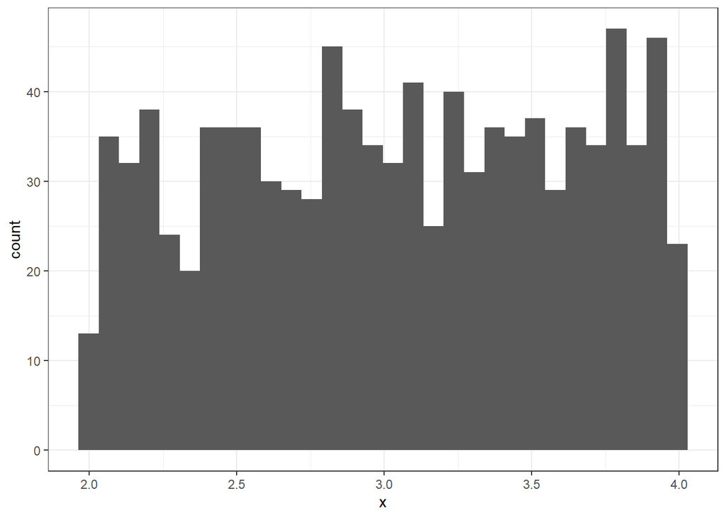

```r
ggplot() +
  geom_histogram(mapping = aes(x = x))
```

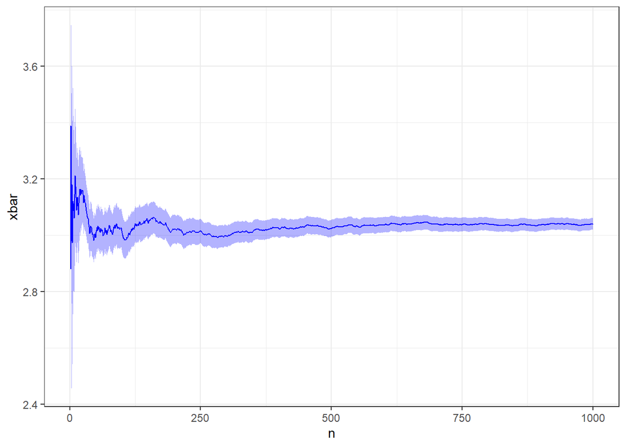

```r
d <- create_mean_dataframe(x)
plot_mean(d)
```

The mean actually can be calculated for a truncated normal

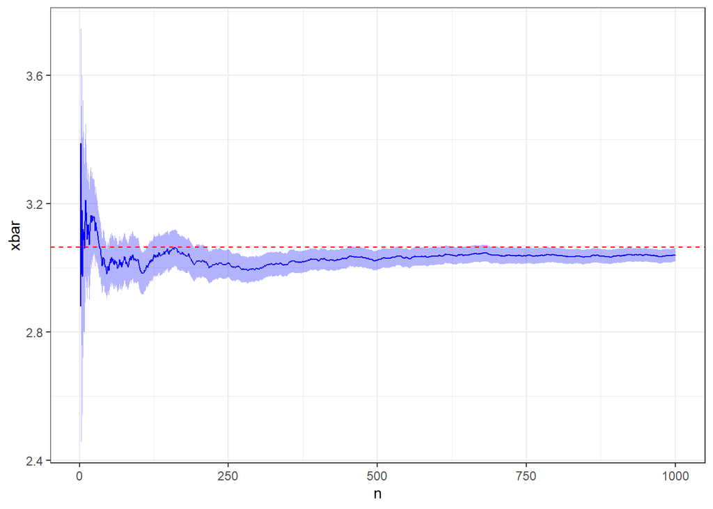

```r
alpha <- (a-m)/s
beta  <- (b-m)/s
mean <- m + (dnorm(alpha)-dnorm(beta))/(pnorm(beta) - pnorm(alpha)) * s
plot_mean(d, truth = mean)
```

### Cauchy mean

**Watch out!**

You need to pay attention to whether the variance is finite amongst your random variables. A Cauchy distribution has no moments and therefore its mean and variance are both undefined. This occurs because the Cauchy distribution has extremely heavy tails.

Let’s use Monte Carlo to try and estimate a Cauchy mean

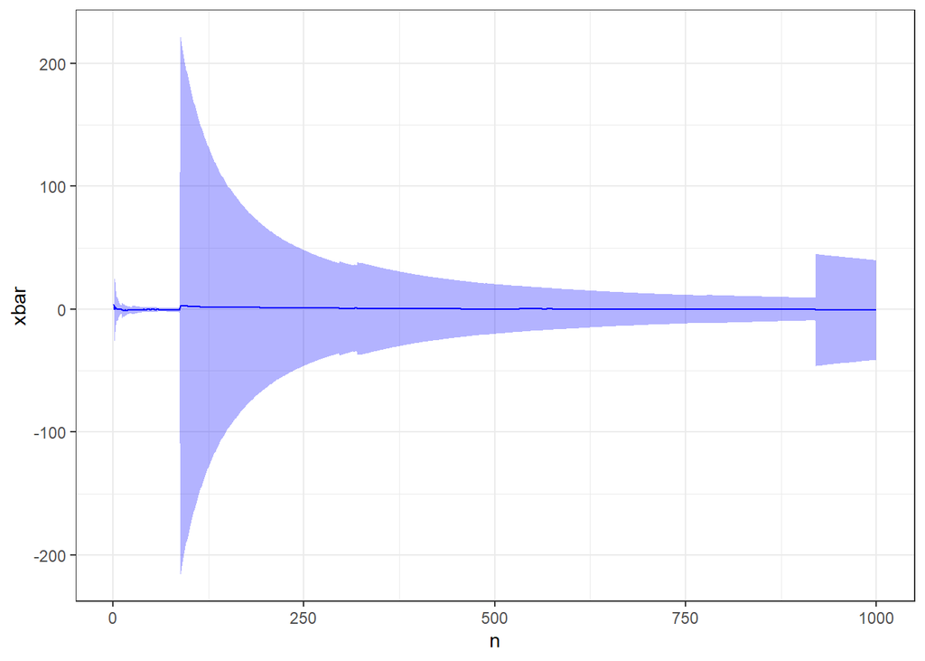

```r
m <- 0
s <- 1

x <- rcauchy(1e3, m, s)

d <- create_mean_dataframe(x)
plot_mean(d)
```

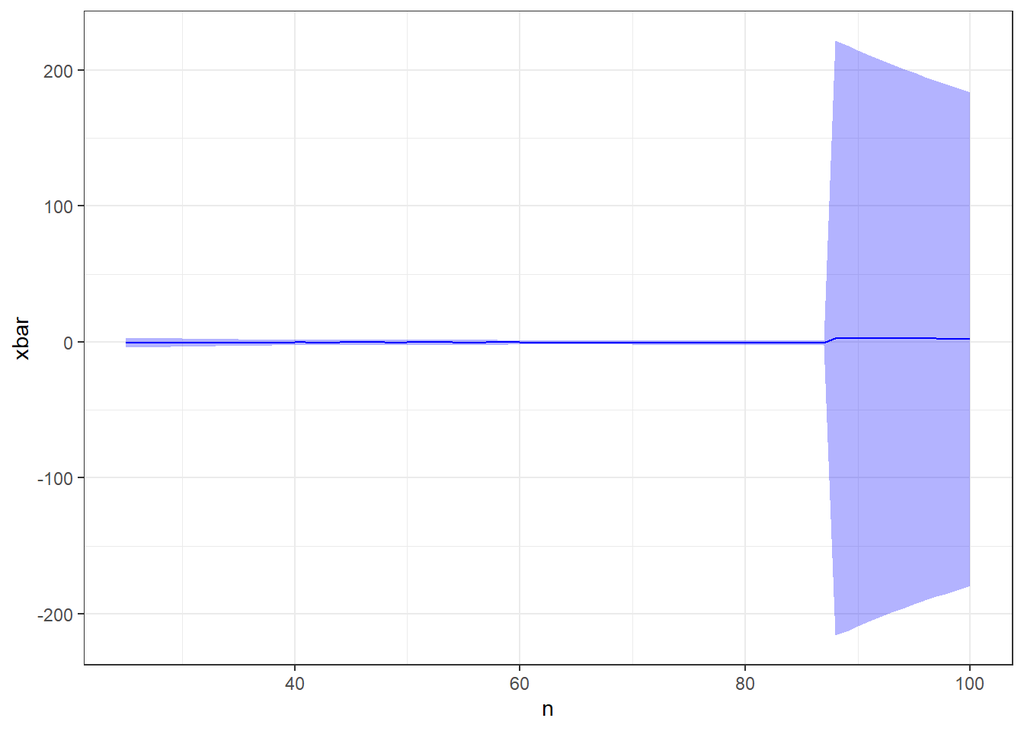

```r
plot_mean(d) + xlim(25,100) # will likely need to adjust the limits
```

The CLT is not relevant here because the variance of the random variables is not finite.

# Proportion

## Central Limit Theorem

If we have $Y \sim Bin(n,\theta)$, then
$$\frac{\hat\theta-\theta}{\sqrt{\frac{\hat\theta(1-\hat\theta)}{n}}}
\stackrel{d}{\to} N(0,1) \quad \mbox{as } n\to \infty.$$
Thus, for large enough n,
$$\hat\theta \stackrel{\cdot}{\sim} N\left(\theta,
\frac{\hat\theta(1-\hat\theta)}{n}\right)$$
where $\stackrel{\cdot}{\sim}$ means “approximately distributed.”

This result is the basis of a common asymptotic confidence interval formula for $\theta$:
$$\hat\theta \pm z \sqrt{\frac{\hat\theta(1-\hat\theta)}{n}}$$
where $z$ is a critical value that depends on the confidence level of the confidence interval.

## Examples

Function to create proportion data frame. The data will be binary (0s and 1s).

```r
create_proportion_dataframe <- function(x) {
  data.frame(n = 1:length(x)) %>%
    mutate(
      theta_hat = cumsum(x)/n,
      se        = sqrt(theta_hat*(1-theta_hat)/n),
      lcl       = theta_hat - qnorm(.975)*se,
      ucl       = theta_hat + qnorm(.975)*se
    )
}
```

and the plot function

```r
plot_proportion <- function(d, truth = NULL) {
  g <- ggplot(d, aes(x = n, y = theta_hat, ymin = lcl, ymax = ucl)) +
    geom_ribbon(fill = "blue", alpha = 0.3) +
    geom_line(color = "blue")

  if (!is.null(truth))
    g <- g + geom_hline(yintercept = truth, color = "red", linetype = 2)

  return(g)
}
```

### Binomial

Let’s generate some Bernoulli data that, when summed, will be binomial.

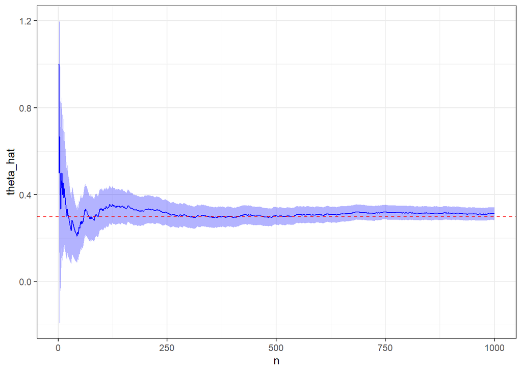

```r
p <- 0.3

x <- rbinom(1e3, size = 1, prob = p)

d <- create_proportion_dataframe(x)
plot_proportion(d, truth = p)
```

### Normal probability

How about the probability a normal random variable is between two end points? Of course, we can calculate the truth here.

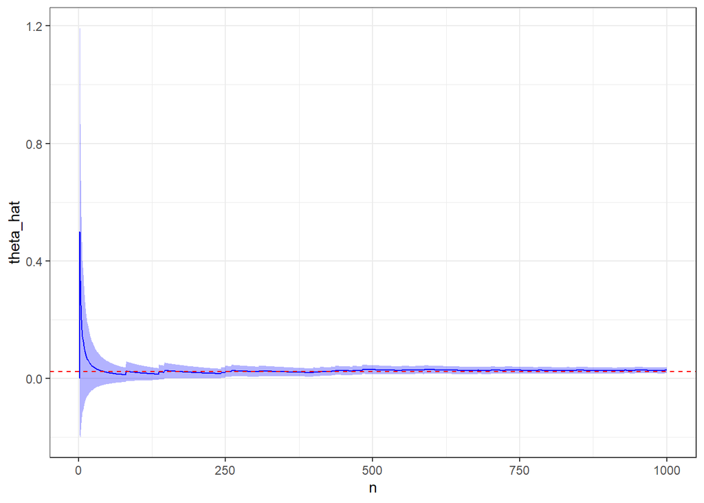

```r
m <- 0
s <- 1
a <- 2
b <- 4

y <- rnorm(1e3, m, s)
x <- a < y & y < b

d <- create_proportion_dataframe(x)
plot_proportion(d, truth = diff(pnorm(c(a,b), mean = m, sd = s)))
```

### Unknown probability

How about the probability that the absolute value of a normal random variable is less than an exponential random variable?

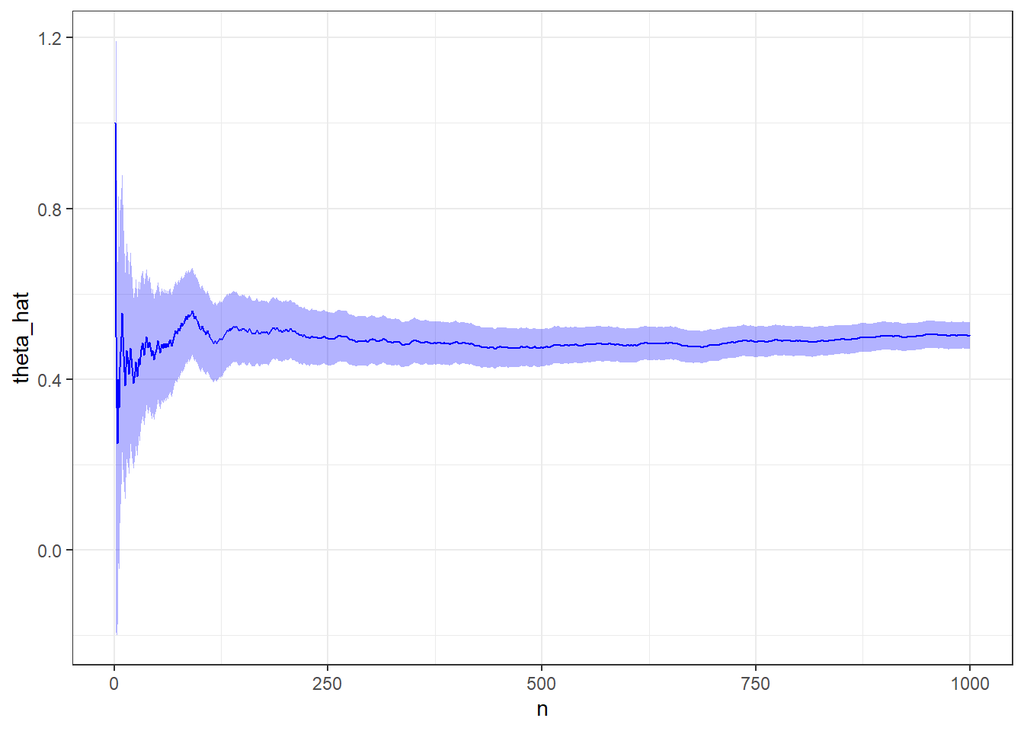

```r
n <- 1e3
y <- rnorm(n)
e <- rexp(n)

x <- abs(y) < e

d <- create_proportion_dataframe(x)
plot_proportion(d)
```